# Generalized Linear Spatio-Temporal Regression

In this Lab we fit a generalized linear spatio-temporal model to yearly counts of Carolina wren in and around the state of Missouri between 1994 and 2014. These counts are part of the BBS data set. We need `gstat`, `sp`, and `spacetime` for fitting an empirical semivariogram to the residuals, `FRK` to construct the basis functions, and the usual packages for wrangling and plotting.

```r
library("ape")
library("FRK")
library("gstat")
library("sp")
library("spacetime")
library("STRbook")
library("tidyverse")
```

## Fitting the Model

The Carolina wren counts in the BBS data set, in both wide and long format, are supplied with `STRbook`. Here we load the data directly in long format and remove any records that contain missing observations.

```r
data("MOcarolinawren_long", package = "STRbook")
MOcarolinawren_long <- MOcarolinawren_long %>%
  filter(!is.na(cnt))
```

We use the same covariates to fit these data as we did to fit the maximum temperature, `Tmax`. Twelve of these covariates were basis functions constructed using `auto_basis` from the package `FRK`. The matrix `S` below then contains the basis functions evaluated at the Carolina wren observation locations.

```r
G <- auto_basis(data = MOcarolinawren_long[,c("lon","lat")] %>%
                  SpatialPoints(), # To sp obj
                nres = 1, # One resolution
                type = "Gaussian") # Gaussian BFs

S <- eval_basis(basis = G, # basis functions
                s = MOcarolinawren_long[,c("lon","lat")] %>%
                  as.matrix()) %>% # conv. to matrix
  as.matrix() # conv. to matrix

colnames(S) <- paste0("B", 1:ncol(S)) # assign column names
```

```r
Wren_df <- cbind(MOcarolinawren_long,S) %>% select(-loc.ID, -t)
Wren_df
```

| cnt | lat | lon | year | B1 | B2 | B3 | B4 | B5 | B6 | B7 | B8 | B9 | B10 | B11 | B12 |
| --- | --- | --- | --- | --- | --- | --- | --- | --- | --- | --- | --- | --- | --- | --- | --- |
| 4 | 36.82526 | -89.24779 | 1994 | 0.002581793 | 0.06761232 | 0.479610310 | 0.9215298267 | 0.001965610 | 0.05147563 | 0.36514414 | 0.701592965 | 0.0003166844 | 0.008293371 | 0.05882931 | 0.113035439 |
| 2 | 36.59369 | -90.74799 | 1994 | 0.035514020 | 0.34839348 | 0.925760041 | 0.6663234104 | 0.022919278 | 0.22483873 | 0.59744721 | 0.430017548 | 0.0031300813 | 0.030706181 | 0.08159325 | 0.058727411 |
| 8 | 36.86373 | -91.68653 | 1994 | 0.115882523 | 0.61503980 | 0.884192303 | 0.3443090711 | 0.090681279 | 0.48128565 | 0.69190493 | 0.269431370 | 0.0150165754 | 0.079699607 | 0.11457759 | 0.044617109 |
| 6 | 36.66086 | -93.91010 | 1994 | 0.714824382 | 0.88517372 | 0.296903895 | 0.0269750032 | 0.483972382 | 0.59930753 | 0.20101900 | 0.018263446 | 0.0693418415 | 0.085866651 | 0.02880129 | 0.002616722 |
| 15 | 36.56423 | -94.23886 | 1994 | 0.822828662 | 0.82165016 | 0.222240244 | 0.0162823353 | 0.519970497 | 0.51922577 | 0.14044038 | 0.010289304 | 0.0695346966 | 0.069435105 | 0.01878083 | 0.001375970 |
| 2 | 37.30663 | -89.52656 | 1994 | 0.003794862 | 0.08280603 | 0.489425105 | 0.7835536376 | 0.004073554 | 0.08888727 | 0.52536823 | 0.841097412 | 0.0009253471 | 0.020191598 | 0.11934245 | 0.191063369 |
| 17 | 37.25986 | -90.30749 | 1994 | 0.015081918 | 0.19739622 | 0.699808661 | 0.6720135485 | 0.015658061 | 0.20493693 | 0.72654199 | 0.697685080 | 0.0034401149 | 0.045025154 | 0.15962308 | 0.153283148 |
| 7 | 37.37596 | -91.55293 | 1994 | 0.083603394 | 0.48426981 | 0.759817172 | 0.3229156141 | 0.094295660 | 0.54620439 | 0.85699227 | 0.364214174 | 0.0225067648 | 0.130369667 | 0.20454943 | 0.086931708 |
| 13 | 37.90398 | -91.42393 | 1994 | 0.054830258 | 0.34558282 | 0.589986696 | 0.2728289969 | 0.090146418 | 0.56817265 | 0.96999704 | 0.448558112 | 0.0313639125 | 0.197679706 | 0.33748321 | 0.156063188 |
| 10 | 37.75110 | -92.03540 | 1994 | 0.120638533 | 0.50957111 | 0.583017744 | 0.1806828685 | 0.177840212 | 0.75118813 | 0.85946005 | 0.266355027 | 0.0554788513 | 0.234339883 | 0.26811628 | 0.083091843 |

[output cut: 773 more lines]

Generalized linear models (GLMs) are fitted in R using the function `glm`. The function works similarly to `lm`, but in addition it requires one to specify the exponential-family model that is used (in this case we consider the Poisson model), as well as the link function (here we use the log function, which is the canonical link). The `glm` function is called as follows.

```r
Wren_GLM <- glm(cnt ~ (lon + lat + year)^2 + ., # formula
                family = poisson("log"), # Poisson + log link
                data = Wren_df) # data set

summary(Wren_GLM)
```

```
Call:
glm(formula = cnt ~ (lon + lat + year)^2 + ., family = poisson("log"),
    data = Wren_df)

Coefficients:
              Estimate Std. Error z value Pr(>|z|)
(Intercept) -1.021e+03  6.114e+02  -1.670 0.094825 .
lon         -4.771e+00  6.417e+00  -0.744 0.457163
lat         -1.134e+01  1.512e+01  -0.750 0.453332
year         1.082e+00  1.370e-01   7.897 2.87e-15 ***
B1           9.715e+00  2.634e+00   3.689 0.000225 ***
B2           8.945e-01  1.007e+00   0.888 0.374506
B3           5.587e+00  1.543e+00   3.620 0.000295 ***
B4          -1.038e+00  1.984e+00  -0.523 0.600795
B5          -2.183e+00  8.839e-01  -2.470 0.013520 *
B6           9.255e+00  1.485e+00   6.233 4.56e-10 ***
B7          -5.412e+00  1.299e+00  -4.165 3.12e-05 ***
B8           1.123e+01  1.865e+00   6.023 1.71e-09 ***
B9           2.000e+01  3.028e+00   6.604 3.99e-11 ***
B10         -7.226e+00  1.513e+00  -4.778 1.77e-06 ***
B11          1.962e+01  2.908e+00   6.747 1.51e-11 ***
B12         -8.253e+00  2.737e+00  -3.015 0.002570 **
lon:lat     -2.787e-01  1.494e-01  -1.865 0.062113 .
lon:year     8.223e-03  1.418e-03   5.800 6.62e-09 ***
lat:year    -8.200e-03  2.559e-03  -3.205 0.001351 **
---
Signif. codes:  0 ‘***’ 0.001 ‘**’ 0.01 ‘*’ 0.05 ‘.’ 0.1 ‘ ’ 1

(Dispersion parameter for poisson family taken to be 1)

    Null deviance: 4579.2  on 782  degrees of freedom
Residual deviance: 2890.1  on 764  degrees of freedom
AIC: 5721.2

Number of Fisher Scoring iterations: 5
```

## Prediction

Prediction proceeds through use of the function `predict`. We first generate our space-time prediction grid, which is an $80 × 80 × 21$ grid in degrees $×$ degrees $×$ years, covering the observations in space and in time.

```r
pred_grid <- expand.grid(lon = seq(
  min(MOcarolinawren_long$lon) - 0.2,
  max(MOcarolinawren_long$lon) + 0.2,
  length.out = 80),
  lat = seq(
    min(MOcarolinawren_long$lat) - 0.2,
    max(MOcarolinawren_long$lat) + 0.2,
    length.out = 80),
  year = 1994:2014)
```

We now evaluate the basis functions at the prediction locations.

```r
S_pred <- eval_basis(basis = G, # basis functs
                     s = pred_grid[,c("lon","lat")] %>% # pred locs
                       as.matrix()) %>% # conv. to matrix
  as.matrix() # as matrix

colnames(S_pred) <- paste0("B", 1:ncol(S_pred)) # assign names

pred_grid <- cbind(pred_grid,S_pred) # attach to grid
```

In the call to `predict` below, we specify `type = "link"` to indicate that we predict the link function of the response and not the response (analogous to the log-intensity of the process).

```r
wren_preds <- predict(Wren_GLM,
                      newdata = pred_grid,
                      type="link",
                      se.fit = TRUE)
```

The predictions of the link function of the response are then attached to our prediction grid for plotting.

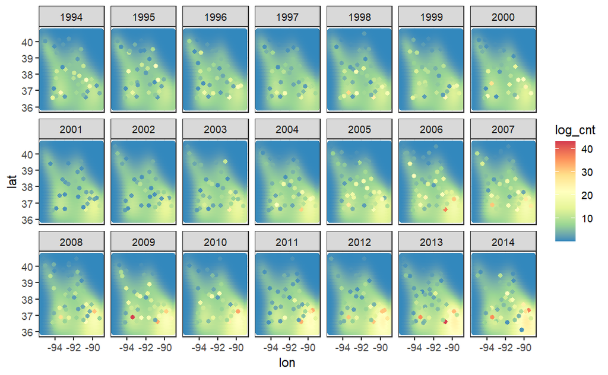

```r
preds <- cbind(pred_grid,log_cnt=wren_preds$fit)

g1 <- ggplot() +
  geom_point(data=preds, aes(lon, lat, colour = exp(log_cnt))) +
  geom_point(data=Wren_df, aes(lon, lat, colour = cnt)) +
  col_scale(name = "log_cnt") +
  facet_wrap(~year, nrow = 3) + theme_bw()

g1
```

When fitting GLMs, it is good practice to check the residuals and inspect them for any residual correlation. The GLM residuals are returned by `residuals`.

```r
Wren_df$residuals <- residuals(Wren_GLM)
```

The plot of the residuals is “noisy,” indicating a lack of spatial correlation.

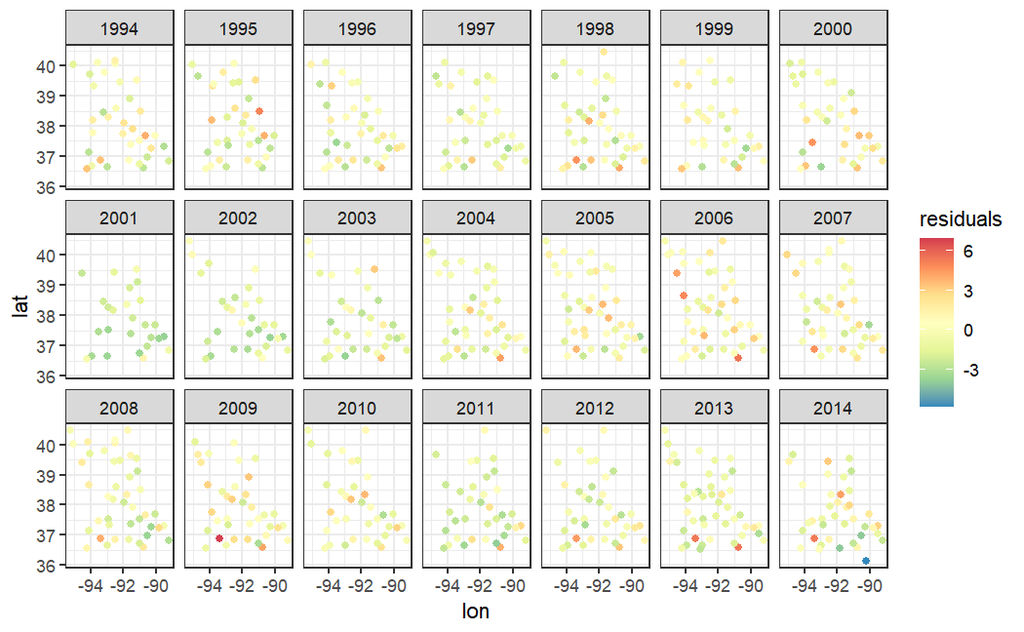

```r
g2 <- ggplot(Wren_df) +
  geom_point(aes(lon, lat, colour = residuals)) +
  col_scale(name = "residuals") +
  facet_wrap(~year, nrow = 3) + theme_bw()

g2
```